# Risk Factor Analysis

## Outcome Variable

**Outcome Variable:** pers_wast

## Predictor Variables

**Intervention Variable:** single

**Adjustment Set:**

unadjusted

## Stratifying Variables

The analysis was stratified on these variable(s):

- agecat
- studyid
- country

## Data Summary

| agecat | studyid | country | single | pers_wast | n_cell | n |
| --- | --- | --- | --- | --- | --- | --- |
| 0-24 months | ki0047075b-MAL-ED | BANGLADESH | 0 | 0 | 235 | 248 |
| 0-24 months | ki0047075b-MAL-ED | BANGLADESH | 0 | 1 | 13 | 248 |
| 0-24 months | ki0047075b-MAL-ED | BANGLADESH | 1 | 0 | 0 | 248 |
| 0-24 months | ki0047075b-MAL-ED | BANGLADESH | 1 | 1 | 0 | 248 |
| 0-24 months | ki0047075b-MAL-ED | BRAZIL | 0 | 0 | 185 | 217 |
| 0-24 months | ki0047075b-MAL-ED | BRAZIL | 0 | 1 | 1 | 217 |
| 0-24 months | ki0047075b-MAL-ED | BRAZIL | 1 | 0 | 30 | 217 |
| 0-24 months | ki0047075b-MAL-ED | BRAZIL | 1 | 1 | 1 | 217 |
| 0-24 months | ki0047075b-MAL-ED | INDIA | 0 | 0 | 218 | 239 |
| 0-24 months | ki0047075b-MAL-ED | INDIA | 0 | 1 | 21 | 239 |
| 0-24 months | ki0047075b-MAL-ED | INDIA | 1 | 0 | 0 | 239 |
| 0-24 months | ki0047075b-MAL-ED | INDIA | 1 | 1 | 0 | 239 |
| 0-24 months | ki0047075b-MAL-ED | NEPAL | 0 | 0 | 234 | 238 |
| 0-24 months | ki0047075b-MAL-ED | NEPAL | 0 | 1 | 4 | 238 |
| 0-24 months | ki0047075b-MAL-ED | NEPAL | 1 | 0 | 0 | 238 |
| 0-24 months | ki0047075b-MAL-ED | NEPAL | 1 | 1 | 0 | 238 |
| 0-24 months | ki0047075b-MAL-ED | PERU | 0 | 0 | 249 | 284 |
| 0-24 months | ki0047075b-MAL-ED | PERU | 0 | 1 | 1 | 284 |
| 0-24 months | ki0047075b-MAL-ED | PERU | 1 | 0 | 34 | 284 |
| 0-24 months | ki0047075b-MAL-ED | PERU | 1 | 1 | 0 | 284 |
| 0-24 months | ki0047075b-MAL-ED | SOUTH AFRICA | 0 | 0 | 154 | 273 |
| 0-24 months | ki0047075b-MAL-ED | SOUTH AFRICA | 0 | 1 | 1 | 273 |
| 0-24 months | ki0047075b-MAL-ED | SOUTH AFRICA | 1 | 0 | 117 | 273 |
| 0-24 months | ki0047075b-MAL-ED | SOUTH AFRICA | 1 | 1 | 1 | 273 |
| 0-24 months | ki0047075b-MAL-ED | TANZANIA, UNITED REPUBLIC OF | 0 | 0 | 244 | 253 |
| 0-24 months | ki0047075b-MAL-ED | TANZANIA, UNITED REPUBLIC OF | 0 | 1 | 0 | 253 |
| 0-24 months | ki0047075b-MAL-ED | TANZANIA, UNITED REPUBLIC OF | 1 | 0 | 9 | 253 |
| 0-24 months | ki0047075b-MAL-ED | TANZANIA, UNITED REPUBLIC OF | 1 | 1 | 0 | 253 |
| 0-24 months | ki1066203-TanzaniaChild2 | TANZANIA, UNITED REPUBLIC OF | 0 | 0 | 1896 | 2148 |
| 0-24 months | ki1066203-TanzaniaChild2 | TANZANIA, UNITED REPUBLIC OF | 0 | 1 | 53 | 2148 |

[output cut: 126 more lines]

The following strata were considered:

- agecat: 0-24 months, studyid: ki0047075b-MAL-ED, country: BANGLADESH
- agecat: 0-24 months, studyid: ki0047075b-MAL-ED, country: BRAZIL
- agecat: 0-24 months, studyid: ki0047075b-MAL-ED, country: INDIA
- agecat: 0-24 months, studyid: ki0047075b-MAL-ED, country: NEPAL
- agecat: 0-24 months, studyid: ki0047075b-MAL-ED, country: PERU
- agecat: 0-24 months, studyid: ki0047075b-MAL-ED, country: SOUTH AFRICA
- agecat: 0-24 months, studyid: ki0047075b-MAL-ED, country: TANZANIA, UNITED REPUBLIC OF
- agecat: 0-24 months, studyid: ki1066203-TanzaniaChild2, country: TANZANIA, UNITED REPUBLIC OF
- agecat: 0-24 months, studyid: ki1112895-Guatemala BSC, country: GUATEMALA
- agecat: 0-24 months, studyid: ki1119695-PROBIT, country: BELARUS
- agecat: 0-24 months, studyid: ki1126311-ZVITAMBO, country: ZIMBABWE
- agecat: 0-24 months, studyid: ki1135781-COHORTS, country: GUATEMALA
- agecat: 0-24 months, studyid: ki1135781-COHORTS, country: INDIA
- agecat: 0-24 months, studyid: ki1135781-COHORTS, country: PHILIPPINES
- agecat: 0-6 months, studyid: ki0047075b-MAL-ED, country: BANGLADESH
- agecat: 0-6 months, studyid: ki0047075b-MAL-ED, country: BRAZIL
- agecat: 0-6 months, studyid: ki0047075b-MAL-ED, country: INDIA
- agecat: 0-6 months, studyid: ki0047075b-MAL-ED, country: NEPAL
- agecat: 0-6 months, studyid: ki0047075b-MAL-ED, country: PERU
- agecat: 0-6 months, studyid: ki0047075b-MAL-ED, country: SOUTH AFRICA
- agecat: 0-6 months, studyid: ki0047075b-MAL-ED, country: TANZANIA, UNITED REPUBLIC OF
- agecat: 0-6 months, studyid: ki1066203-TanzaniaChild2, country: TANZANIA, UNITED REPUBLIC OF
- agecat: 0-6 months, studyid: ki1119695-PROBIT, country: BELARUS
- agecat: 0-6 months, studyid: ki1126311-ZVITAMBO, country: ZIMBABWE
- agecat: 0-6 months, studyid: ki1135781-COHORTS, country: PHILIPPINES
- agecat: 6-24 months, studyid: ki0047075b-MAL-ED, country: BANGLADESH
- agecat: 6-24 months, studyid: ki0047075b-MAL-ED, country: BRAZIL
- agecat: 6-24 months, studyid: ki0047075b-MAL-ED, country: INDIA
- agecat: 6-24 months, studyid: ki0047075b-MAL-ED, country: NEPAL
- agecat: 6-24 months, studyid: ki0047075b-MAL-ED, country: PERU
- agecat: 6-24 months, studyid: ki0047075b-MAL-ED, country: SOUTH AFRICA
- agecat: 6-24 months, studyid: ki0047075b-MAL-ED, country: TANZANIA, UNITED REPUBLIC OF
- agecat: 6-24 months, studyid: ki1066203-TanzaniaChild2, country: TANZANIA, UNITED REPUBLIC OF
- agecat: 6-24 months, studyid: ki1112895-Guatemala BSC, country: GUATEMALA
- agecat: 6-24 months, studyid: ki1119695-PROBIT, country: BELARUS
- agecat: 6-24 months, studyid: ki1126311-ZVITAMBO, country: ZIMBABWE
- agecat: 6-24 months, studyid: ki1135781-COHORTS, country: GUATEMALA
- agecat: 6-24 months, studyid: ki1135781-COHORTS, country: INDIA
- agecat: 6-24 months, studyid: ki1135781-COHORTS, country: PHILIPPINES

### Dropped Strata

Some strata were dropped due to rare outcomes:

- agecat: 0-24 months, studyid: ki0047075b-MAL-ED, country: BANGLADESH
- agecat: 0-24 months, studyid: ki0047075b-MAL-ED, country: BRAZIL
- agecat: 0-24 months, studyid: ki0047075b-MAL-ED, country: INDIA
- agecat: 0-24 months, studyid: ki0047075b-MAL-ED, country: NEPAL
- agecat: 0-24 months, studyid: ki0047075b-MAL-ED, country: PERU
- agecat: 0-24 months, studyid: ki0047075b-MAL-ED, country: SOUTH AFRICA
- agecat: 0-24 months, studyid: ki0047075b-MAL-ED, country: TANZANIA, UNITED REPUBLIC OF
- agecat: 0-24 months, studyid: ki1112895-Guatemala BSC, country: GUATEMALA
- agecat: 0-24 months, studyid: ki1135781-COHORTS, country: GUATEMALA
- agecat: 0-24 months, studyid: ki1135781-COHORTS, country: INDIA
- agecat: 0-6 months, studyid: ki0047075b-MAL-ED, country: BANGLADESH
- agecat: 0-6 months, studyid: ki0047075b-MAL-ED, country: BRAZIL
- agecat: 0-6 months, studyid: ki0047075b-MAL-ED, country: INDIA
- agecat: 0-6 months, studyid: ki0047075b-MAL-ED, country: NEPAL
- agecat: 0-6 months, studyid: ki0047075b-MAL-ED, country: PERU
- agecat: 0-6 months, studyid: ki0047075b-MAL-ED, country: SOUTH AFRICA
- agecat: 0-6 months, studyid: ki0047075b-MAL-ED, country: TANZANIA, UNITED REPUBLIC OF
- agecat: 0-6 months, studyid: ki1126311-ZVITAMBO, country: ZIMBABWE
- agecat: 0-6 months, studyid: ki1135781-COHORTS, country: PHILIPPINES
- agecat: 6-24 months, studyid: ki0047075b-MAL-ED, country: BANGLADESH
- agecat: 6-24 months, studyid: ki0047075b-MAL-ED, country: BRAZIL
- agecat: 6-24 months, studyid: ki0047075b-MAL-ED, country: INDIA
- agecat: 6-24 months, studyid: ki0047075b-MAL-ED, country: NEPAL
- agecat: 6-24 months, studyid: ki0047075b-MAL-ED, country: PERU
- agecat: 6-24 months, studyid: ki0047075b-MAL-ED, country: SOUTH AFRICA
- agecat: 6-24 months, studyid: ki0047075b-MAL-ED, country: TANZANIA, UNITED REPUBLIC OF
- agecat: 6-24 months, studyid: ki1112895-Guatemala BSC, country: GUATEMALA
- agecat: 6-24 months, studyid: ki1135781-COHORTS, country: GUATEMALA
- agecat: 6-24 months, studyid: ki1135781-COHORTS, country: INDIA

## Methods Detail

We’re interested in the causal parameters $E[Y_a]$ for all values of $a \in \mathcal{A}$. These parameters represent the mean outcome if, possibly contrary to fact, we intervened to set all units to have $A=a$. Under the randomization and positivity assumptions, these are identified by the statistical parameters $\psi_a=E_W[E_{Y|A,W}(Y|A=a,W)]$. In addition, we’re interested in the mean of $Y$, $E[Y]$ under no intervention (the observed mean). We will estimate these parameters by using SuperLearner to fit the relevant likelihood factors – $E_{Y|A,W}(Y|A=a,W)$ and $p(A=a|W)$, and then updating our likelihood fit using a joint TMLE.

For unadjusted analyses ($W=\{\}$), initial likelihoods were estimated using Lrnr_glm to estimate the simple $E(Y|A)$ and Lrnr_mean to estimate $p(A)$. For adjusted analyses, a small library containing Lrnr_glmnet, Lrnr_xgboost, and Lrnr_mean was used.

Having estimated these parameters, we will then use the delta method to estimate relative risks and attributable risks relative to a prespecified baseline level of $A$.

# Results Detail

## Results Plots

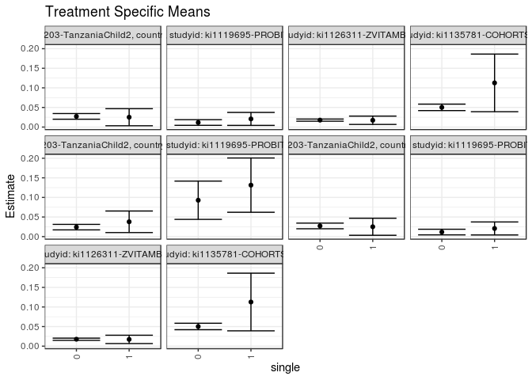

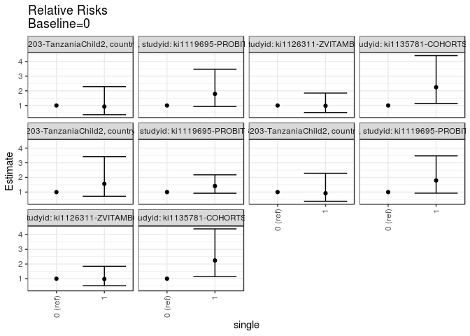

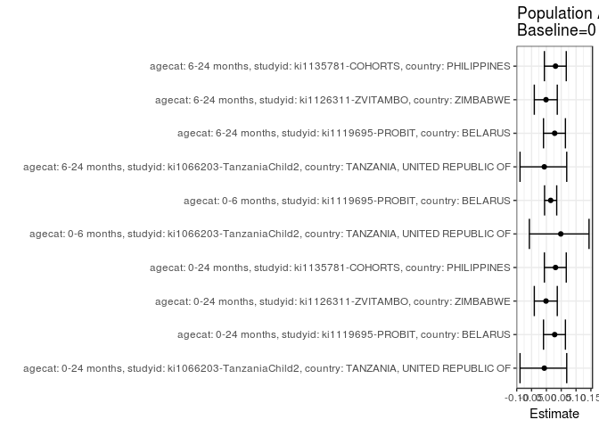

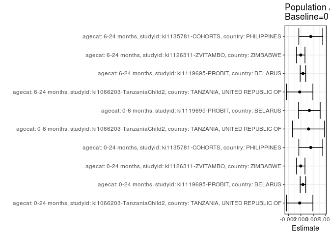

## Results Table

### Parameter: TSM

| agecat | studyid | country | intervention_level | baseline_level | estimate | ci_lower | ci_upper |
| --- | --- | --- | --- | --- | --- | --- | --- |
| 0-24 months | ki1066203-TanzaniaChild2 | TANZANIA, UNITED REPUBLIC OF | 0 | NA | 0.0271934 | 0.0199709 | 0.0344159 |
| 0-24 months | ki1066203-TanzaniaChild2 | TANZANIA, UNITED REPUBLIC OF | 1 | NA | 0.0251256 | 0.0033758 | 0.0468754 |
| 0-24 months | ki1119695-PROBIT | BELARUS | 0 | NA | 0.0115840 | 0.0043737 | 0.0187944 |
| 0-24 months | ki1119695-PROBIT | BELARUS | 1 | NA | 0.0207612 | 0.0041857 | 0.0373368 |
| 0-24 months | ki1126311-ZVITAMBO | ZIMBABWE | 0 | NA | 0.0176666 | 0.0149010 | 0.0204323 |
| 0-24 months | ki1126311-ZVITAMBO | ZIMBABWE | 1 | NA | 0.0173010 | 0.0066705 | 0.0279315 |
| 0-24 months | ki1135781-COHORTS | PHILIPPINES | 0 | NA | 0.0502401 | 0.0420098 | 0.0584704 |
| 0-24 months | ki1135781-COHORTS | PHILIPPINES | 1 | NA | 0.1126761 | 0.0391140 | 0.1862381 |
| 0-6 months | ki1066203-TanzaniaChild2 | TANZANIA, UNITED REPUBLIC OF | 0 | NA | 0.0242066 | 0.0172184 | 0.0311947 |
| 0-6 months | ki1066203-TanzaniaChild2 | TANZANIA, UNITED REPUBLIC OF | 1 | NA | 0.0378378 | 0.0103364 | 0.0653393 |
| 0-6 months | ki1119695-PROBIT | BELARUS | 0 | NA | 0.0928204 | 0.0439662 | 0.1416747 |
| 0-6 months | ki1119695-PROBIT | BELARUS | 1 | NA | 0.1313559 | 0.0620885 | 0.2006234 |
| 6-24 months | ki1066203-TanzaniaChild2 | TANZANIA, UNITED REPUBLIC OF | 0 | NA | 0.0271934 | 0.0199709 | 0.0344159 |
| 6-24 months | ki1066203-TanzaniaChild2 | TANZANIA, UNITED REPUBLIC OF | 1 | NA | 0.0251256 | 0.0033758 | 0.0468754 |
| 6-24 months | ki1119695-PROBIT | BELARUS | 0 | NA | 0.0115840 | 0.0043737 | 0.0187944 |
| 6-24 months | ki1119695-PROBIT | BELARUS | 1 | NA | 0.0207612 | 0.0041857 | 0.0373368 |
| 6-24 months | ki1126311-ZVITAMBO | ZIMBABWE | 0 | NA | 0.0176666 | 0.0149010 | 0.0204323 |
| 6-24 months | ki1126311-ZVITAMBO | ZIMBABWE | 1 | NA | 0.0173010 | 0.0066705 | 0.0279315 |
| 6-24 months | ki1135781-COHORTS | PHILIPPINES | 0 | NA | 0.0502401 | 0.0420098 | 0.0584704 |
| 6-24 months | ki1135781-COHORTS | PHILIPPINES | 1 | NA | 0.1126761 | 0.0391140 | 0.1862381 |

### Parameter: E(Y)

| agecat | studyid | country | intervention_level | baseline_level | estimate | ci_lower | ci_upper |
| --- | --- | --- | --- | --- | --- | --- | --- |
| 0-24 months | ki1066203-TanzaniaChild2 | TANZANIA, UNITED REPUBLIC OF | NA | NA | 0.0270019 | 0.0201456 | 0.0338581 |
| 0-24 months | ki1119695-PROBIT | BELARUS | NA | NA | 0.0119167 | 0.0046062 | 0.0192272 |
| 0-24 months | ki1126311-ZVITAMBO | ZIMBABWE | NA | NA | 0.0176439 | 0.0149673 | 0.0203205 |
| 0-24 months | ki1135781-COHORTS | PHILIPPINES | NA | NA | 0.0518359 | 0.0435904 | 0.0600814 |
| 0-6 months | ki1066203-TanzaniaChild2 | TANZANIA, UNITED REPUBLIC OF | NA | NA | 0.0254403 | 0.0186125 | 0.0322681 |
| 0-6 months | ki1119695-PROBIT | BELARUS | NA | NA | 0.0941866 | 0.0454872 | 0.1428859 |
| 6-24 months | ki1066203-TanzaniaChild2 | TANZANIA, UNITED REPUBLIC OF | NA | NA | 0.0270019 | 0.0201456 | 0.0338581 |
| 6-24 months | ki1119695-PROBIT | BELARUS | NA | NA | 0.0119167 | 0.0046062 | 0.0192272 |
| 6-24 months | ki1126311-ZVITAMBO | ZIMBABWE | NA | NA | 0.0176439 | 0.0149673 | 0.0203205 |
| 6-24 months | ki1135781-COHORTS | PHILIPPINES | NA | NA | 0.0518359 | 0.0435904 | 0.0600814 |

### Parameter: RR

| agecat | studyid | country | intervention_level | baseline_level | estimate | ci_lower | ci_upper |
| --- | --- | --- | --- | --- | --- | --- | --- |
| 0-24 months | ki1066203-TanzaniaChild2 | TANZANIA, UNITED REPUBLIC OF | 0 | 0 | 1.0000000 | 1.0000000 | 1.000000 |
| 0-24 months | ki1066203-TanzaniaChild2 | TANZANIA, UNITED REPUBLIC OF | 1 | 0 | 0.9239594 | 0.3736040 | 2.285042 |
| 0-24 months | ki1119695-PROBIT | BELARUS | 0 | 0 | 1.0000000 | 1.0000000 | 1.000000 |
| 0-24 months | ki1119695-PROBIT | BELARUS | 1 | 0 | 1.7922320 | 0.9263434 | 3.467500 |
| 0-24 months | ki1126311-ZVITAMBO | ZIMBABWE | 0 | 0 | 1.0000000 | 1.0000000 | 1.000000 |
| 0-24 months | ki1126311-ZVITAMBO | ZIMBABWE | 1 | 0 | 0.9793062 | 0.5194511 | 1.846258 |
| 0-24 months | ki1135781-COHORTS | PHILIPPINES | 0 | 0 | 1.0000000 | 1.0000000 | 1.000000 |
| 0-24 months | ki1135781-COHORTS | PHILIPPINES | 1 | 0 | 2.2427506 | 1.1440794 | 4.396487 |
| 0-6 months | ki1066203-TanzaniaChild2 | TANZANIA, UNITED REPUBLIC OF | 0 | 0 | 1.0000000 | 1.0000000 | 1.000000 |
| 0-6 months | ki1066203-TanzaniaChild2 | TANZANIA, UNITED REPUBLIC OF | 1 | 0 | 1.5631231 | 0.7150723 | 3.416933 |
| 0-6 months | ki1119695-PROBIT | BELARUS | 0 | 0 | 1.0000000 | 1.0000000 | 1.000000 |
| 0-6 months | ki1119695-PROBIT | BELARUS | 1 | 0 | 1.4151618 | 0.9205352 | 2.175564 |
| 6-24 months | ki1066203-TanzaniaChild2 | TANZANIA, UNITED REPUBLIC OF | 0 | 0 | 1.0000000 | 1.0000000 | 1.000000 |
| 6-24 months | ki1066203-TanzaniaChild2 | TANZANIA, UNITED REPUBLIC OF | 1 | 0 | 0.9239594 | 0.3736040 | 2.285042 |
| 6-24 months | ki1119695-PROBIT | BELARUS | 0 | 0 | 1.0000000 | 1.0000000 | 1.000000 |
| 6-24 months | ki1119695-PROBIT | BELARUS | 1 | 0 | 1.7922320 | 0.9263434 | 3.467500 |
| 6-24 months | ki1126311-ZVITAMBO | ZIMBABWE | 0 | 0 | 1.0000000 | 1.0000000 | 1.000000 |
| 6-24 months | ki1126311-ZVITAMBO | ZIMBABWE | 1 | 0 | 0.9793062 | 0.5194511 | 1.846258 |
| 6-24 months | ki1135781-COHORTS | PHILIPPINES | 0 | 0 | 1.0000000 | 1.0000000 | 1.000000 |
| 6-24 months | ki1135781-COHORTS | PHILIPPINES | 1 | 0 | 2.2427506 | 1.1440794 | 4.396487 |

### Parameter: PAR

| agecat | studyid | country | intervention_level | baseline_level | estimate | ci_lower | ci_upper |
| --- | --- | --- | --- | --- | --- | --- | --- |
| 0-24 months | ki1066203-TanzaniaChild2 | TANZANIA, UNITED REPUBLIC OF | 0 | NA | -0.0001916 | -0.0023149 | 0.0019318 |
| 0-24 months | ki1119695-PROBIT | BELARUS | 0 | NA | 0.0003327 | -0.0001125 | 0.0007779 |
| 0-24 months | ki1126311-ZVITAMBO | ZIMBABWE | 0 | NA | -0.0000227 | -0.0007058 | 0.0006603 |
| 0-24 months | ki1135781-COHORTS | PHILIPPINES | 0 | NA | 0.0015957 | -0.0003313 | 0.0035227 |
| 0-6 months | ki1066203-TanzaniaChild2 | TANZANIA, UNITED REPUBLIC OF | 0 | NA | 0.0012338 | -0.0013401 | 0.0038076 |
| 0-6 months | ki1119695-PROBIT | BELARUS | 0 | NA | 0.0013661 | -0.0003810 | 0.0031132 |
| 6-24 months | ki1066203-TanzaniaChild2 | TANZANIA, UNITED REPUBLIC OF | 0 | NA | -0.0001916 | -0.0023149 | 0.0019318 |
| 6-24 months | ki1119695-PROBIT | BELARUS | 0 | NA | 0.0003327 | -0.0001125 | 0.0007779 |
| 6-24 months | ki1126311-ZVITAMBO | ZIMBABWE | 0 | NA | -0.0000227 | -0.0007058 | 0.0006603 |
| 6-24 months | ki1135781-COHORTS | PHILIPPINES | 0 | NA | 0.0015957 | -0.0003313 | 0.0035227 |

### Parameter: PAF

| agecat | studyid | country | intervention_level | baseline_level | estimate | ci_lower | ci_upper |
| --- | --- | --- | --- | --- | --- | --- | --- |
| 0-24 months | ki1066203-TanzaniaChild2 | TANZANIA, UNITED REPUBLIC OF | 0 | NA | -0.0070947 | -0.0888621 | 0.0685324 |
| 0-24 months | ki1119695-PROBIT | BELARUS | 0 | NA | 0.0279181 | -0.0097289 | 0.0641614 |
| 0-24 months | ki1126311-ZVITAMBO | ZIMBABWE | 0 | NA | -0.0012885 | -0.0407595 | 0.0366855 |
| 0-24 months | ki1135781-COHORTS | PHILIPPINES | 0 | NA | 0.0307844 | -0.0068119 | 0.0669768 |
| 0-6 months | ki1066203-TanzaniaChild2 | TANZANIA, UNITED REPUBLIC OF | 0 | NA | 0.0484959 | -0.0573614 | 0.1437553 |
| 0-6 months | ki1119695-PROBIT | BELARUS | 0 | NA | 0.0145046 | -0.0062048 | 0.0347877 |
| 6-24 months | ki1066203-TanzaniaChild2 | TANZANIA, UNITED REPUBLIC OF | 0 | NA | -0.0070947 | -0.0888621 | 0.0685324 |
| 6-24 months | ki1119695-PROBIT | BELARUS | 0 | NA | 0.0279181 | -0.0097289 | 0.0641614 |
| 6-24 months | ki1126311-ZVITAMBO | ZIMBABWE | 0 | NA | -0.0012885 | -0.0407595 | 0.0366855 |
| 6-24 months | ki1135781-COHORTS | PHILIPPINES | 0 | NA | 0.0307844 | -0.0068119 | 0.0669768 |